# PIT - Práctica 1: Análisis de Series Temporales - Modelos Clásicos

**Profesora: Alicia Lozano Díez**

**Alumno: José Antonio Álvarez Ocete**

14 de febrero de 2022

## Objetivo

El objetivo de esta práctica es proporcionar una introducción al procesamiento y análisis de señales temporales: descomposición de una serie temporal para el estudio de sus propiedades, ajuste de modelos lineales (ARIMA) y predicción.

### Materiales - Moodle

- Guión (.ipynb) de la práctica
- Datos (.csv): bases de datos *AirPassengers.csv* y *COVIDVaccinationCZ.csv*.

```python
import numpy as np
```

# 1. Introducción al procesamiento de señales temporales: Air Passengers

## 1.1. Cargar los datos en Google Colab y manejo de los datos en Python

Primero vamos a descargar el fichero con los datos de la base de datos *AirPassengers.csv* de Moodle, que contiene los datos del número de pasajeros de una aerolínea para un periodo de tiempo.

Las siguientes líneas de código nos permitirán subir el archivo a Google Colab desde el disco local:

```python
# from google.colab import files
# uploaded = files.upload()
```

A continuación, vamos a leer el fichero *AirPassengers.csv* en Python, con la ayuda de la librería *pandas*.

Lo cargaremos haciendo uso también del módulo de Python *datetime* para operar con este tipo de datos de forma cómoda.

La función definida *parser* nos permitirá cambiar el formato de fecha/tiempo al formato que esperamos encontrar en nuestra base de datos.

```python
from pandas import read_csv
from datetime import datetime

def parser(x):
    return datetime.strptime(x, '%Y-%m')

data = read_csv('inputs/AirPassengers.csv', header=0, parse_dates=[0], index_col=0,
                squeeze=True, date_parser=parser)
print(data.head())
```

```
Month
1949-01-01    112
1949-02-01    118
1949-03-01    132
1949-04-01    129
1949-05-01    121
Name: #Passengers, dtype: int64
```

Podemos visualizar cómo está indexada la estructura de datos, así como el número de datos que tiene nuestra serie temporal.

```python
data.index
```

```
DatetimeIndex(['1949-01-01', '1949-02-01', '1949-03-01', '1949-04-01',
               '1949-05-01', '1949-06-01', '1949-07-01', '1949-08-01',
               '1949-09-01', '1949-10-01',
               ...
               '1960-03-01', '1960-04-01', '1960-05-01', '1960-06-01',
               '1960-07-01', '1960-08-01', '1960-09-01', '1960-10-01',
               '1960-11-01', '1960-12-01'],
              dtype='datetime64[ns]', name='Month', length=144, freq=None)
```

Si queremos acceder a un dato en concreto, por ejemplo, el número de pasajeros del mes de marzo de 1949, podemos hacerlo de la siguiente forma:

```python
data['1949-03-01']
```

```
132
```

O de esta otra:

```python
data[datetime(1949,3,1)]
```

```
132
```

## 1.2. Representación de los datos

El primer paso para analizar una serie temporal es obtener una representación de los datos, para poder hacernos una idea de las características de la serie de forma visual.

Para ello, podemos utilizar la librería *matplotlib* como sigue:

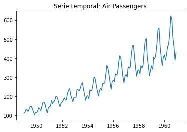

```python
import matplotlib.pyplot as plt
plt.plot(data)
_ = plt.title('Serie temporal: Air Passengers')
```

## 1.3. Estudio de la estacionariedad de la serie

Algunos de los modelos de análisis de series temporales asumen estacionariedad en las series. Por ello, vamos a ver dos métodos para comprobar si una serie es estacionaria.

Uno de ellos es un análisis más visual: calculamos la media y desviación estándar "móviles" (con una ventana deslizante).

```python
import pandas as pd

def test_stationarity_1(timeseries, window_size):
    #Determing rolling statistics
    rolmean = timeseries.rolling(window=window_size).mean()
    rolstd = timeseries.rolling(window=window_size).std()

    #Plot rolling statistics:
    orig = plt.plot(timeseries, color='blue',label='Original')
    mean = plt.plot(rolmean, color='red', label='Rolling Mean')
    std = plt.plot(rolstd, color='black', label = 'Rolling Std')
    plt.legend(loc='best')
    plt.title(
        'Rolling Mean & Standard Deviation (window size = {})'.format(window_size))
    plt.show(block=False)
```

El segundo método consiste en el test estadístico Dickey-Fuller:

```python
import pandas as pd

from statsmodels.tsa.stattools import adfuller
def test_stationarity_2(timeseries):
    # Perform Dickey-Fuller test:
    print('Results of Dickey-Fuller Test:')
    dftest = adfuller(timeseries, autolag='AIC')
    dfoutput = pd.Series(dftest[0:4], index=['Test Statistic','p-value','#Lags Used','Number of Observations Used'])
    for key,value in dftest[4].items():
        dfoutput['Critical Value (%s)'%key] = value
    print(dfoutput)
```

```python
def test_stationarity(timeseries, window_size):
  test_stationarity_1(timeseries, window_size)
  test_stationarity_2(timeseries)
```

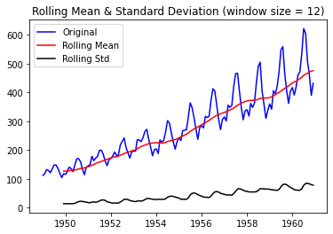

```
Results of Dickey-Fuller Test:
Test Statistic                   0.815369
p-value                          0.991880
#Lags Used                      13.000000
Number of Observations Used    130.000000
Critical Value (1%)             -3.481682
Critical Value (5%)             -2.884042
Critical Value (10%)            -2.578770
dtype: float64
```

```python
test_stationarity(data, 12)
```

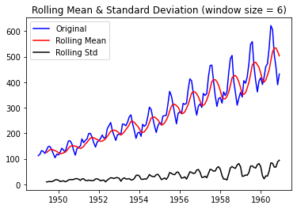

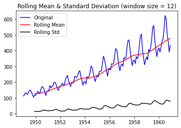

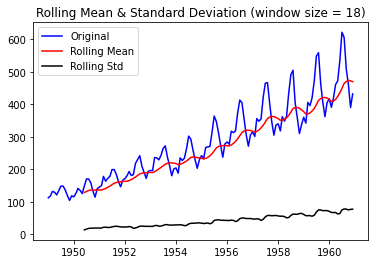

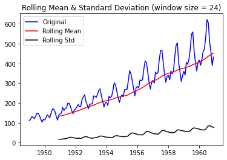

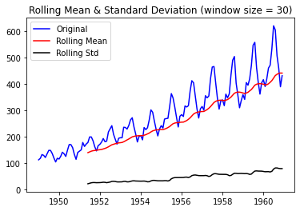

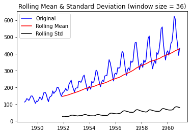

```python
for window_size in range(6, 37, 6):
    test_stationarity_1(data, window_size)
```

**PREGUNTAS**

1. ¿Qué conclusiones puede extraer del análisis de estacionariedad de la serie original?
2. ¿Qué diferencias observas al variar el tamaño de la ventana para hacer las medias móviles? Prueba con un par de tamaños, incluye las gráficas obtenidas y explica las diferencias visuales que aprecias.

**RESPUESTAS**

**Pregunta 1**

El análisis en la serie original revela una media estacionaria creciente de forma lineal, al menos visualmente. También podemos apreciar como la desviación típica también es creciente. En revela que el número medio de viajeros en los últimos años aumenta con el tiempo, como cabría esperar.

Por otro lado, el test Dickey-Fuller presenta como hipótesis nula que la serie no es estacionaria. Obteniendo un *p-value* de $0.99$, deducimos que los datos no muestra evidencia suficiente para rechazar la hipótesis nula para nivel de confianza de hasta el $99\%$. Es decir, la serie no es estacionaria. Aunque visualmente apreciamos que tanto la media como la desviación típica parecen variar, el test no nos indica cuál de estos parámetros hace que la serie no sea estacionaria.

Para simplificar futuros análisis merece la pena aclarar el uso del test Dickey-Fuller y el *p-value*:

- Si el *p-value* es menor que el nivel de significación $\alpha$ ($0.1$, $0.05$ o $0.01$ normalmente), rechazamos la hipótesis nula. Es decir, **deducimos que la serie es estacionaria** con nivel de confianza $1 - \alpha$.
- Si el *p-value* es mayor que el nivel de significación $\alpha$, aceptamos la hipótesis nula. Es decir, **deducimos que la serie no es estacionaria** con nivel de confianza $1 - \alpha$.

**Pregunta 2**

Si prestamos atención a los cambios en la media podemos apreciar como para ciertos valores esta oscila más que para otros, casi independientemente del tamaño de la ventana para valores altos del mismo. Esto se debe a que nuestra serie presencia un periodo de un año (12 meses), y al tomar tamaños de ventana múltiplos de dicho valor reducimos bien dicha oscilación. Sin embargo, al tomar tamaños de ventana no múltiplos de 12 meses introducimos cierta variabilidad: conforme movemos la ventana pillaremos más veranos que inviernos y viceversa, añadiendo variación a la estimación.

En definitiva, un buen valor de ventana es aquel que coincide con el periodo de la componente estacional de la serie temporal, o un múltiplo de la misma. A ser posible el periodo para reducir el sesgo en nuestra estimación.

## 1.4. Transformar una serie temporal en estacionaria

Como hemos visto en la teoría, para analizar la serie y poder ajustarle un modelo tipo AR, MA o ARMA, esperamos que la serie a modelar sea estacionaria.

Para conseguir una serie lo más estacionaria posible, podemos aplicar distintas transformaciones de la serie original. Vamos a ver algunos ejemplos:

a) *Transformaciones simples para reducir el efecto de la tendendia*:

En el caso de los datos del ejemplo, la tendencia es positiva, por lo que podemos aplicar alguna transformación que penalice los valores más altos y menos los más bajos. Es el caso del logaritmo, la raíz cuadrada, etc.

**PREGUNTA**

1. Representa a continuación la serie aplicándole una transformación logarítmica. ¿Qué observas?

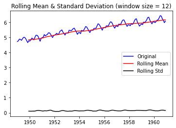

```python
data_log = data.apply(np.log)
test_stationarity_1(data_log, 12)
```

**RESPUESTA**

Observamos como la serie definitvamente se ha aplanado, pero sigue presentando una componente creciente y una componente estacional. En la desviación típica si podemos observamos como, a pesar de mantener ciertas perturbaciones, es prácticamente constante. Si apreciamos como los máximos y mínimos son aproximadamente del mismo tamaño, mientras que en la serie original aumentaban la distancia entre sí (esto es equivalente a la constancia de la desviación típica).

En casos más complejos en los que la tendencia no se ve clara (sobre todo en presencia de ruido), se pueden aplicar otros métodos. Uno de ellos es el suavizado como las medias móviles (*moving average*).

Por ejemplo, podemos aplicar un suavizado con una media con ventana deslizante que tenga en cuenta un año (12 meses). Ten en cuenta, que esto implicará que para calcular la media de las primeras muestras, no tengo suficientes datos para la ventana. Esto lo podemos ver en la salida de la media móvil (tendremos que eliminar los *NaN* que aparecen).

**PREGUNTAS**

1. Aplica dicha media móvil y represéntala junto a los datos. Puede utilizar los datos en escala logarítmica. ¿Esta media móvil representa claramente la tendencia de la serie?
2. Elimina ahora de la serie original (transformada con el logaritmo si es como la has calculado previamente) la influencia de esta media móvil y representa el resultado. ¿Qué observas ahora?
3. Realiza el test de estacionariedad de la serie resultante y compáralo con el de la serie original. ¿Qué conclusiones puedes obtener tanto del test visual como del test estadístico?

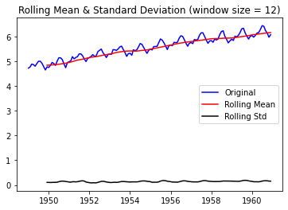

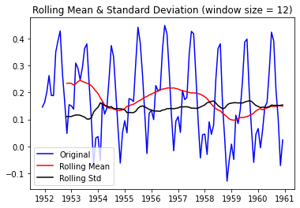

```
Results of Dickey-Fuller Test:
Test Statistic                 -2.433236
p-value                         0.132575
#Lags Used                     13.000000
Number of Observations Used    95.000000
Critical Value (1%)            -3.501137
Critical Value (5%)            -2.892480
Critical Value (10%)           -2.583275
dtype: float64
```

```python
# 1. Rolling mean of logged data
test_stationarity_1(data_log, 12)

# 2. Normalize logged data by substracting the rolling mean
rol_mean = data_log.rolling(window=window_size).mean()
normalized_data_log = (data_log - rol_mean).dropna()

# 3. Plot the normalized data and
# compute the Dickey-Fuller test
test_stationarity(normalized_data_log, 12)
```

**RESPUESTAS**

**Pregunta 1.**

Como analizamos en la pregunta anterior, esta media se ajusta mucho mejor a los datos (logaritmizados) que la anterior y reduce la desviación típica notablemente, por lo que representa fehacientemente la tendencia de la serie temporal.

**Pregunta 2.**

**Pregunta 3.**

En este caso obtenemos un *p-value* de $\sim 0.13$, significativamente menor que en los casos anteriores pero aún así no deducimos que esta serie sea estacionaria ni con un nivel de significación del $0.1$.

b) *Diferenciar (derivar)*:

Las técnicas anteriores son sencillas y pueden eliminar parte de la influencia de la tendencia de la serie, pero no suelen ser suficientes cuando se tiene por ejemplo estacionalidad.

Diferenciar (o derivar) es uno de los métodos más comunes para eliminar la influencia de la tendencia y la estacionalidad en la serie original, mejorando las propiedades de estacionariedad de la serie.

Podemos tomar la derivada de orden uno de la siguiente manera (partimos de la serie en el dominio logarítmico):

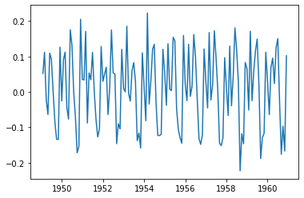

```python
data_log_diff = (data_log - data_log.shift()).dropna()
_ = plt.plot(data_log_diff)
```

**PREGUNTAS**

1. ¿Qué observas en la serie resultante?
2. ¿Es esta serie estacionaria de acuerdo a los criterios anteriores? Incluye los resultados gráficos y del test estadístico e interprétalos.
3. Repite el proceso para una segunda derivada. ¿Qué observas ahora?

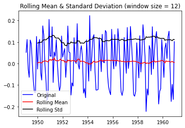

```
Results of Dickey-Fuller Test:
Test Statistic                  -2.717131
p-value                          0.071121
#Lags Used                      14.000000
Number of Observations Used    128.000000
Critical Value (1%)             -3.482501
Critical Value (5%)             -2.884398
Critical Value (10%)            -2.578960
dtype: float64
```

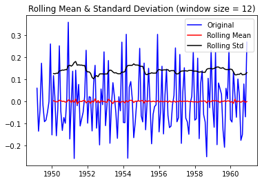

```
Results of Dickey-Fuller Test:
Test Statistic                -8.196629e+00
p-value                        7.419305e-13
#Lags Used                     1.300000e+01
Number of Observations Used    1.280000e+02
Critical Value (1%)           -3.482501e+00
Critical Value (5%)           -2.884398e+00
Critical Value (10%)          -2.578960e+00
dtype: float64
```

```python
# 2. Compute the Dickey-Fuller test for the
# logged derivated data
test_stationarity(data_log_diff, 12)

# 3. Compute the Dickey-Fuller test for the
# second derivative
data_log_diff_2 = (data_log_diff - data_log_diff.shift()).dropna()
test_stationarity(data_log_diff_2, 12)
```

**RESPUESTAS**

**Pregunta 1.**

En la serie derivada observamos que la media deslizante es prácticamente cero, y la desviación típica se ha reducido considerablemente. Sin embargo, a pesar de poder observar la componente estacional (ciertos máximos y mínimos más diferenciados del resto se repite de forma periódica), también observamos muchísima variabilidad en el resto de valores de la serie, sobretodo en comparación con la serie a la que aplicamos el logarítmo y le restamos la media.

**Pregunta 2.**

Visualmente, la media y la desviación típica son prácticamente constantes, por lo que podríamos deducir que lo es. Sin embargo, el test de Dickey-Fuller obtiene un *p-value* de $0.07$. Aunque menor que en el caso anterior, con nivel de confianza $0.95$ no aceptaríamos que esta serie es estacionaria, aunque si lo haríamos con nivel de confianza $0.9$. En resumen, la serie es aparentemente estacionaria pero no podemos asegurarlo con total confianza.

**Pregunta 3.**

En el caso de la segunda derivada visualmente perdemos por completo la componente estacional y obtenemos únicamente los residuos. Esta serie es obviamente estacionaria, se comprueba tanto en la media y desviación típica calculadas como en el test computado, con un *p-value* de $\sim 7.41 \cdot 10^{-13}$.

c) *Descomposición de la serie*:

La mayoría de series pueden descomponerse en tendencia, estacionalidad y residuo, como hemos visto en clase.

Utilizando la función *seasonal_decompose* del módulo de Python *statsmodels* podemos obtener estas tres componentes y por tanto, modelarlas por separado:

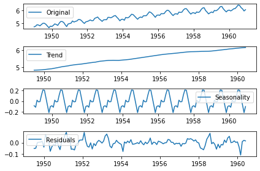

```python
from statsmodels.tsa.seasonal import seasonal_decompose

def decompose_time_series(data):
    decomposition = seasonal_decompose(data)

    trend = decomposition.trend.dropna()
    seasonal = decomposition.seasonal.dropna()
    residual = decomposition.resid.dropna()

    plt.subplot(411)
    plt.plot(data_log, label='Original')
    plt.legend(loc='best')
    plt.subplot(412)
    plt.plot(trend, label='Trend')
    plt.legend(loc='best')
    plt.subplot(413)
    plt.plot(seasonal,label='Seasonality')
    plt.legend(loc='best')
    plt.subplot(414)
    plt.plot(residual, label='Residuals')
    plt.legend(loc='best')
    plt.tight_layout()

    return trend, seasonal, residual

trend, seasonal, residual = decompose_time_series(data_log)
```

**PREGUNTAS**

1. ¿Es la señal residual estacionaria? Realiza el test y comenta los resultados.

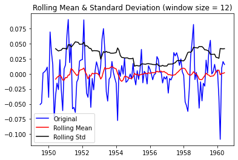

```
Results of Dickey-Fuller Test:
Test Statistic                -6.332387e+00
p-value                        2.885059e-08
#Lags Used                     9.000000e+00
Number of Observations Used    1.220000e+02
Critical Value (1%)           -3.485122e+00
Critical Value (5%)           -2.885538e+00
Critical Value (10%)          -2.579569e+00
dtype: float64
```

```python
test_stationarity(residual, 12)
```

**RESPUESTA**

Observamos tanto a partir de la gráfica como del test Dickey-Fuller que la serie residual obtenida es estacionaria, pues tenemos un *p-value* muy reducido.

## 1.5. Modelado ARIMA y predicción

Uno de los modelos clásicos para series temporales vistos en clase es el modelo ARIMA, que permite derivar *d* veces, y aplicar *p* coeficientes autorregresivos (AR) y *q* términos de error (shocks, provenientes de la parte MA) en la combinación lineal.

Para determinar el valor de los parámetros *p* y *q*, podemos hacer uso de las funciones de autocorrelación (ACF) y autocorrelación parcial (PACF).

Si calculamos dichas funciones para la serie derivada previamente, obtenemos lo siguiente:

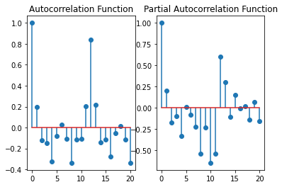

```python
#ACF and PACF plots:
from statsmodels.tsa.stattools import acf, pacf

def plot_acf_pacf(data):
    lag_acf = acf(data, nlags=20, fft=False)
    lag_pacf = pacf(data, nlags=20, method='ols')

    #Plot ACF:
    plt.subplot(121)
    plt.stem(lag_acf,use_line_collection=True)
    plt.title('Autocorrelation Function')

    #Plot PACF:
    plt.subplot(122)
    plt.stem(lag_pacf,use_line_collection=True)
    _ = plt.title('Partial Autocorrelation Function')

plot_acf_pacf(data_log_diff)
```

Podemos añadir además un intervalo de confianza a ambos lados del valor cero, de tal manera que el primer valor de retardo que cruce ese intervalo por arriba en la función de PACF será el valor de *p*, y de ACF, será *q*.

Para los niveles de confianza estándar, el valor del límite del intervalo de confianza al 95% es 1.96. Suponiendo desviación estándar unidad, el límite estaría en (-1.96/sqrt(N), 1.96/sqrt(N)), donde N es el número de puntos.

Si incluimos estos límites en la figura anterior, podemos obtener una buena aproximación de los valores de *p* y *q* para el modelo ARIMA:

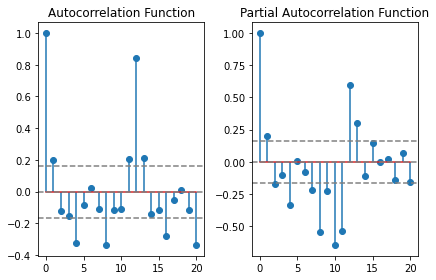

```python
def plot_acf_pacf_with_interval(data):
    lag_acf = acf(data, nlags=20, fft=False)
    lag_pacf = pacf(data, nlags=20, method='ols')

    #Plot ACF:
    plt.subplot(121)
    plt.stem(lag_acf,use_line_collection=True)
    plt.axhline(y=0,linestyle='--',color='gray')
    plt.axhline(y=-1.96/np.sqrt(len(data_log_diff)),linestyle='--',color='gray')
    plt.axhline(y=1.96/np.sqrt(len(data_log_diff)),linestyle='--',color='gray')
    plt.title('Autocorrelation Function')

    #Plot PACF:
    plt.subplot(122)
    plt.stem(lag_pacf,use_line_collection=True)
    plt.axhline(y=0,linestyle='--',color='gray')
    plt.axhline(y=-1.96/np.sqrt(len(data_log_diff)),linestyle='--',color='gray')
    plt.axhline(y=1.96/np.sqrt(len(data_log_diff)),linestyle='--',color='gray')
    plt.title('Partial Autocorrelation Function')
    plt.tight_layout()

plot_acf_pacf_with_interval(data_log_diff)
```

**PREGUNTAS**

1. ¿Qué valores de *p* y *q* utilizarías para un primer modelo ARIMA de acuerdo a las representaciones anteriores?

**RESPUESTA**

Una vez elegidos los valores de *p* y *q*, podemos utilizar también la derivación interna de la clase ARIMA (*d*) o aplicarlo sobre la serie previamente derivada con valor de *d=0*.

A continuación, importamos el modelo ARIMA de la siguiente manera.

Este modelo tiene como argumentos los datos, y el orden:

model = ARIMA(datos, order = (p,d,q))

```python
from statsmodels.tsa.arima.model import ARIMA

# Resample the dataset so the ARIMA model creation
# doesn't complain about not obtaining freq information.
data_log_diff = data_log_diff.resample('MS').last()
```

**PREGUNTAS**

1. A continuación, completa los valores de p, d y q y utiliza el siguiente código para ajustar un modelo tipo AR. Incluye el resultado en el informe de la práctica así como los valores elegidos. ¿Qué error de ajuste (RSS) se obtiene?
2. Repite el código con los valores de los parámetros correspondientes para ajustar un modelo MA. Incluye el resultado en el informe de la práctica así como los valores elegidos. ¿Qué error de ajuste (RSS) se obtiene?
3. Repite nuevamente el código para combinar los modelos anteriores (ARMA). Incluye el resultado en el informe de la práctica así como los valores elegidos. ¿Qué error de ajuste (RSS) se obtiene?
4. De acuerdo a los valores de RSS, ¿cuál dirías que es el modelo que mejor se ajusta a los datos?

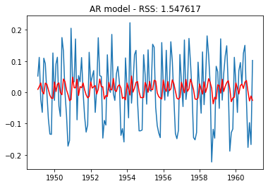

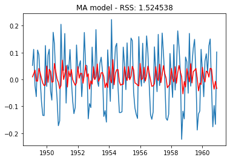

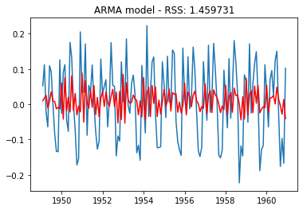

```python
def plot_ARIMA_model(data, p, d, q, model_name, freq='MS'):
    model = ARIMA(data, order=(p, d, q), freq=freq, enforce_invertibility=True)

    # Fitting the model.
    fitted_model = model.fit()

    # Plotting
    plt.plot(data)
    plt.plot(fitted_model.fittedvalues, color='red')
    # RSS: Residual sum of squares
    plt.title('{} model - RSS: {:4f}'.format(model_name,
        np.sum((fitted_model.fittedvalues - data)**2)))
    plt.show()

    return fitted_model

def plot_AR_model(data, p=1, d=0, q=0, freq='MS'):
    return plot_ARIMA_model(data, p=p, d=d, q=q, model_name='AR', freq=freq)

def plot_MA_model(data, p=0, d=0, q=1, freq='MS'):
    return plot_ARIMA_model(data, p=p, d=d, q=q, model_name='MA', freq=freq)

def plot_ARMA_model(data, p=1, d=0, q=1, freq='MS'):
    return plot_ARIMA_model(data, p=p, d=d, q=q, model_name='ARMA', freq=freq)

plot_AR_model(data_log_diff)
plot_MA_model(data_log_diff)
results_ARIMA = plot_ARMA_model(data_log_diff)
```

**RESPUESTAS**

Respondemos a las tres primeras preguntas utilizando la siguiente tabla:

| Modelo | RSS |
| --- | --- |
| AR | 1.5476 |
| MA | 1.5245 |
| ARMA | 1.4597 |

De acuerdo a esta métrica, el modelo que se ajusta mejor a los datos derivados es el modelo ARMA (es decir, el modelo ARIMA para los datos originales).

Por último, para predecir valores en el espacio original, tenemos que deshacer las transformaciones realizadas hasta el momento.

Primero, tomamos los valores ajustados por el modelo (predicciones) y los guardamos como serie temporal.

Estos valores empiezan en el segundo mes, puesto que hemos tomado diferencias (derivada) de orden 1.

```python
# Predicciones en el espacio original
predictions_ARIMA_diff = pd.Series(results_ARIMA.fittedvalues, copy=True)
print(predictions_ARIMA_diff.head())
```

```
Month
1949-02-01    0.009797
1949-03-01    0.017616
1949-04-01    0.025227
1949-05-01   -0.010229
1949-06-01    0.008525
Freq: MS, dtype: float64
```

Segundo, deshacemos la operación de diferencias (en escala logarítmica), con una suma acumulativa y añadiéndoles el valor "base" (primer elemento de la serie).

```python
predictions_ARIMA_diff_cumsum = predictions_ARIMA_diff.cumsum()
print(predictions_ARIMA_diff_cumsum.head(), '\n')

predictions_ARIMA_log = pd.Series(data_log[0], index=data_log.index)
predictions_ARIMA_log = predictions_ARIMA_log.add(predictions_ARIMA_diff_cumsum, fill_value=0)
print(predictions_ARIMA_log.head())
```

```
Month
1949-02-01    0.009797
1949-03-01    0.027412
1949-04-01    0.052639
1949-05-01    0.042410
1949-06-01    0.050935
Freq: MS, dtype: float64

Month
1949-01-01    4.718499
1949-02-01    4.728295
1949-03-01    4.745911
1949-04-01    4.771138
1949-05-01    4.760909
dtype: float64
```

Finalmente, aplicamos la función exponencial (inversa del logaritmo).

Podemos calcular el error cuadrático medio en el espacio original.

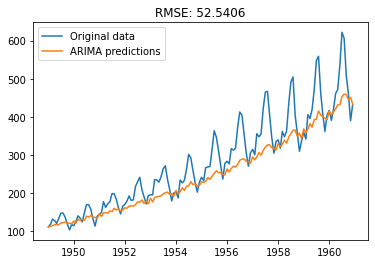

```python
predictions_ARIMA = np.exp(predictions_ARIMA_log)
plt.plot(data, label='Original data')
plt.plot(predictions_ARIMA, label='ARIMA predictions')
plt.legend()
_ = plt.title('RMSE: %.4f'% np.sqrt(sum((predictions_ARIMA-data)**2)/len(data)))
```

# 2. Aplicación a otros datos: Vacunación COVID República Checa

Vamos a cargar ahora los datos sobre la vacunación COVID de República Checa (*COVIDVaccinationCZ.csv*):

```python
# from google.colab import files
# uploaded = files.upload()
```

Esta base de datos, contiene los datos de vacunación de República Checa desde el 27 de diciembre de 2020 hasta el 7 de febrero de 2022.

```python
from pandas import read_csv
from datetime import datetime
import matplotlib.pyplot as plt

def parser(x):
    return datetime.strptime(x, '%Y-%m-%d')

data_vac = read_csv('inputs/COVIDVaccinationCZ.csv', header=0, parse_dates=[0], index_col=0, squeeze=True, date_parser=parser)
print(data.head())
```

```
Month
1949-01-01    112
1949-02-01    118
1949-03-01    132
1949-04-01    129
1949-05-01    121
Name: #Passengers, dtype: int64
```

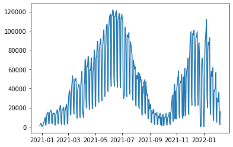

```python
from matplotlib import pyplot as plt
_ = plt.plot(data_vac)
```

**PREGUNTAS**

Utilizando las herramientas del apartado 1, realiza el análisis de esta serie (puedes utilizar un intervalo de ella o la serie completa).

En concreto:

1. Analiza la estacionariedad de esta serie.
2. ¿Qué transformaciones puedes realizar para hacerla más estacionaria? Prueba algunas y justifica si consigues una serie más estacionaria.
3. Ajusta un modelo ARIMA, y calcula el error de predicción.

### 1. Estacionariedad de la serie.

Realizamos un análisis preliminar para verificar si la serie en estudio es estacionaria o no.

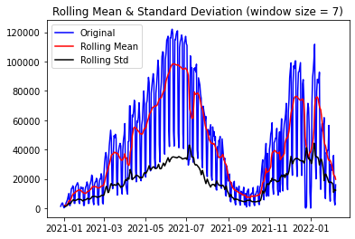

```
Results of Dickey-Fuller Test:
Test Statistic                  -2.052545
p-value                          0.264019
#Lags Used                      14.000000
Number of Observations Used    393.000000
Critical Value (1%)             -3.447099
Critical Value (5%)             -2.868923
Critical Value (10%)            -2.570703
dtype: float64
```

```python
test_stationarity(data_vac, 7)
```

En primer lugar, he seleccionado $7$ como valor para el tamaño de ventana pues minimiza las ondulaciones en la rolling mean. Esto podría significar que el periodo de la parte estacionaria es de $7$ días o una semana: entre semana la vacunación es notablemente mayor que en fin de semana, de ahí las grandes subidas y bajadas que se aprecian en la serie.

En segundo lugar, la serie no es visualmente estacionaria (ni la media ni la desviación típica se acercan a ser constantes). El test de Dickey-Fuller confirma esta hipótesis obteniendo un *p-value* de $\sim 0.26 > 0.1 = \alpha$. Por lo tanto, **deducimos que la serie no es estacionaria**.

### 2. Transformaciones para estacionar la serie.

Probamos con las trasnformaciones realizadas en el ejercicio anterior: aplicamos logaritmo a la serie y calculamos su derivada.

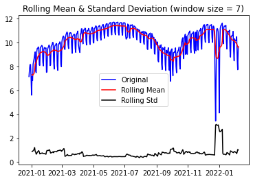

```
Results of Dickey-Fuller Test:
Test Statistic                  -3.447442
p-value                          0.009444
#Lags Used                       7.000000
Number of Observations Used    400.000000
Critical Value (1%)             -3.446804
Critical Value (5%)             -2.868793
Critical Value (10%)            -2.570634
dtype: float64
```

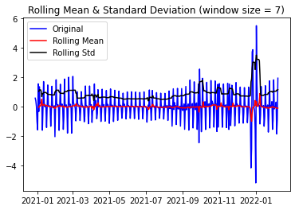

```
Results of Dickey-Fuller Test:
Test Statistic                -1.094922e+01
p-value                        8.885075e-20
#Lags Used                     6.000000e+00
Number of Observations Used    4.000000e+02
Critical Value (1%)           -3.446804e+00
Critical Value (5%)           -2.868793e+00
Critical Value (10%)          -2.570634e+00
dtype: float64
```

```python
data_vac_log = data_vac.apply(np.log)
test_stationarity(data_vac_log, 7)

data_vac_log_diff = (data_vac_log - data_vac_log.shift()).dropna()
test_stationarity(data_vac_log_diff, 7)
```

Tras aplicar logaritmo a nuestra serie temporal obtenemos una serie que a pesar de no parecer visualmente estacionaria obtiene un *p-value* en el test de Dickey-Fuller de $\sim 0.009$, revelando una serie analíticamente estacionaria con nivel de confianza $0.99$.

Aunque podríamos trabajar con esta serie, la derivamos para encontrar una serie aún más estacionaria. El resultado es tanto visual como analíticamente esclarecedor: la serie obtenido es definitivamente estacionaria.

Aunque trabajaremos con esta serie por lo conocida que es para nosotros tras el ejercicio anterior, podemos descomponer la serie utilizando la función `decompose_time_series()` de la librería `statsmodels` para comparar los resultados.

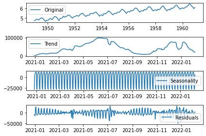

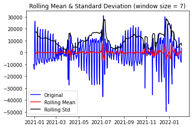

```
Results of Dickey-Fuller Test:
Test Statistic                -1.003963e+01
p-value                        1.508231e-17
#Lags Used                     1.100000e+01
Number of Observations Used    3.900000e+02
Critical Value (1%)           -3.447229e+00
Critical Value (5%)           -2.868980e+00
Critical Value (10%)          -2.570733e+00
dtype: float64
```

```python
trend_residual, seasonal_vac, residuals_vac = decompose_time_series(data_vac)
plt.show()

test_stationarity(residuals_vac, 7)
```

Obtenemos una serie de residuos similar a la computada tras aplicar logaritmo y derivar, posiblemente sin la influencia del logarítimo mirando la escala. Como hemos comentado, trabajaremos con la primera pues estamos más familiarizados con ella.

### 3. Ajuste de modelo ARIMA utilizando logaritmo y derivadas

He de aclarar que la primera aproximación a este apartado fue el ajustar un modelo ARMA a la serie derivada manualmente (ajustando un modelo ARIMA en conjunto), pero obtenía resultados notablemente peores en la predicción. Es por ello que he decidido ajustar el modelo ARIMA a los datos con el logaritmo aplicado y utilizando el parámetro $d=1$.

En primer lugar calculamos las funciones de autocorrelación y autocorrelación parcial para obtener los valores de $p$ y $q$ que utilizar en nuestro modelo. Como ajustaremos un modelo ARMA a las derivadas, calculamos dichas funciones para los datos derivados manualmente.

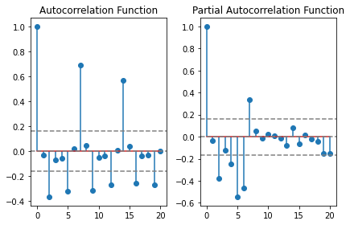

```python
plot_acf_pacf_with_interval(data_vac_log_diff)
```

En vista de las gráficas anteriores tomaremos los valores $p=2$ y $q=2$ pues son los menores valores por encima del límite impuesto.

A continuación ajustamos el modelo ARIMA a los datos sin derivar con el parámetro $d=1$.

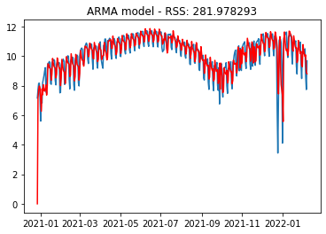

```python
data_vac_log = data_vac_log.resample('D').last()
results_ARIMA_vac = plot_ARMA_model(data_vac_log, p=2, d=1, q=2, freq='D')
```

A continuación mostramos las predicciones obtenidas en el espacio original en el que las realizamos.

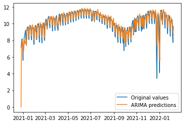

```python
# Predictions in the original space
predictions_ARIMA_vac = pd.Series(results_ARIMA_vac.fittedvalues, copy=True)

plt.plot(data_vac_log, label='Original values')
plt.plot(predictions_ARIMA_vac, label='ARIMA predictions')
_ = plt.legend()
```

Finalmente aplicamos la exponencial a nuestro datos para deshacer el logaritmo y los comparamos con los datos originales.

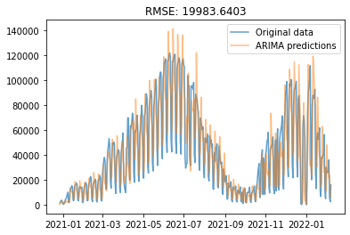

```python
# Undo the logarithm by applying an exponential
predictions_ARIMA_vac = predictions_ARIMA_vac.apply(np.exp)

plt.plot(data_vac, label='Original data', alpha=0.7)
plt.plot(predictions_ARIMA_vac, label='ARIMA predictions', alpha=0.5)
plt.legend()
_ = plt.title('RMSE: %.4f'% np.sqrt(np.sum((predictions_ARIMA_vac - data_vac)**2)/len(data_vac)))
```

### 4. Ajuste de un modelo SARIMA

El ajuste realizado anteriormente no utiliza la información del problema que vimos en primera instacia: hay una periodicidad semanal en nuestros datos que podríamos tener en cuenta en nuestro problema. Para integrar esta información sobre preciodicidad utilizaremos un modelo SARIMA con periodo $s=7$ y parámetros $(P,D,Q) = (2,1,2)$ (mimetizando los parámetros del modelo ARIMA original).

```python
from statsmodels.tsa.statespace.sarimax import SARIMAX

def plot_SARIMA_model(data, p=1, d=0, q=1, P=0, D=0, Q=0, period=1, freq='D'):
    model = SARIMAX(data, order=(p, d, q), seasonal_order=(P,D,Q,period),
                   freq=freq, enforce_invertibility=True)
    model_name = 'SARIMA'

    # Fitting the model.
    fitted_model = model.fit()

    # Plotting
    plt.plot(data)
    plt.plot(fitted_model.fittedvalues, color='red')
    # RSS: Residual sum of squares
    plt.title('{} model - RSS: {:4f}'.format(model_name,
        np.sum((fitted_model.fittedvalues - data)**2)))
    plt.show()

    return fitted_model
```

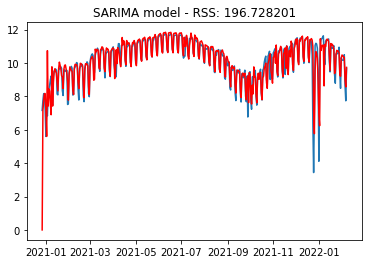

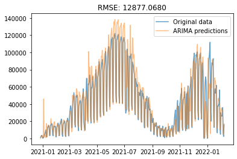

```python
results_SARIMA = plot_SARIMA_model(data_vac_log, p=2, d=1, q=2,
                                   P=2, D=1, Q=2, period=7)

# Undo the logarithm by applying an exponential
predictions_SARIMA = pd.Series(results_SARIMA.fittedvalues, copy=True)
predictions_SARIMA = predictions_SARIMA.apply(np.exp)

plt.plot(data_vac, label='Original data', alpha=0.7)
plt.plot(predictions_SARIMA, label='ARIMA predictions', alpha=0.5)
plt.legend()
_ = plt.title('RMSE: %.4f'% np.sqrt(np.sum((predictions_SARIMA - data_vac)**2)/len(data_vac)))
```